# 218194

*N* removed NAs: 2

*N* removed typo: 1

*N* removed <18: 28

*N* total clean: 119

| Group | *N* | *M*<sub>age</sub> | *M*<sub>rating</sub> |
| --- | --- | --- | --- |
| Control | 61 | 20.5 | 6.12 |
| Experim | 58 | 20.2 | 5.28 |

**Main analysis results**

*t*(117) = 5.51, *p* < .001

[interactive chart not shown]

[figure not shown]

[interactive chart not shown]

# 218194

Analysing Data, Spring 2020

# Methods

## Participants

Table 1. *Descriptive statistics by Condition*

| Condition | *N* | *%* | *M*<sub>age</sub> | *SD*<sub>age</sub> |
| --- | --- | --- | --- | --- |
| White | 61 | 51.3 | 20.5 | 1.85 |
| Red | 58 | 48.7 | 20.2 | 1.57 |

## Design

The present study arises from the research question about whether or not men’s attractiveness can be influenced by colours. Our conceptual hypothesis states that woman attraction to men increases with the presence of colour red. The study consisted of a between-subjects design. A black-and-white photo of a man was shown to participants for 5 seconds. There was one independent categorical variable (the colour of the area around the photo) with two conditions: red and white frame. Participants were randomly assigned to one of these conditions: 61 viewed the photo surrounded by a white frame, whereas 58 participants viewed the same photo with a red frame. There was one dependent continuous variable: perceived attractiveness. Perceived attractiveness is a composite score obtained by averaging the mean scores of three attractiveness ratings. All three attractiveness ratings’ scores ranged from 1 (not at all attractive) to 9 (extremely attractive). These ratings answered the following questions: “How attractive do you think the person is?”, “How pleasant is this person to look at?” and “If you were to meet the person in this picture face to face, would you think this person is attractive?”. Therefore, our operational hypothesis is that participants in the red condition will report different perceived attractiveness scores compared to those in the white condition. In order to test this hypothesis, I will run an independent-samples *t*-test.

# Results

An independent-measures *t*-test was used to investigate whether attractiveness ratings would vary between participants in the red and those in the white condition. The results showed a significant difference between the two groups’ mean attractiveness ratings (see Table 2), with higher scores in the white condition group ((*M*<sub>diff</sub> = 0.84, 95% CI [0.54, 1.15], *t* (117) = 5.51, *p*<.001)). Thus, these results (displayed in Figure 1) reject our hypotheses and put forward that women tend to consider a man as more attractive in relation to colour white.

Table 2. *Mean attractiveness scores and composite score by Condition*

| Condition | Score 1 | Score 2 | Score 3 | Composite Score |
| --- | --- | --- | --- | --- |
| White | 6.11 | 6.08 | 6.16 | 6.12 |
| Red | 5.14 | 5.38 | 5.31 | 5.28 |

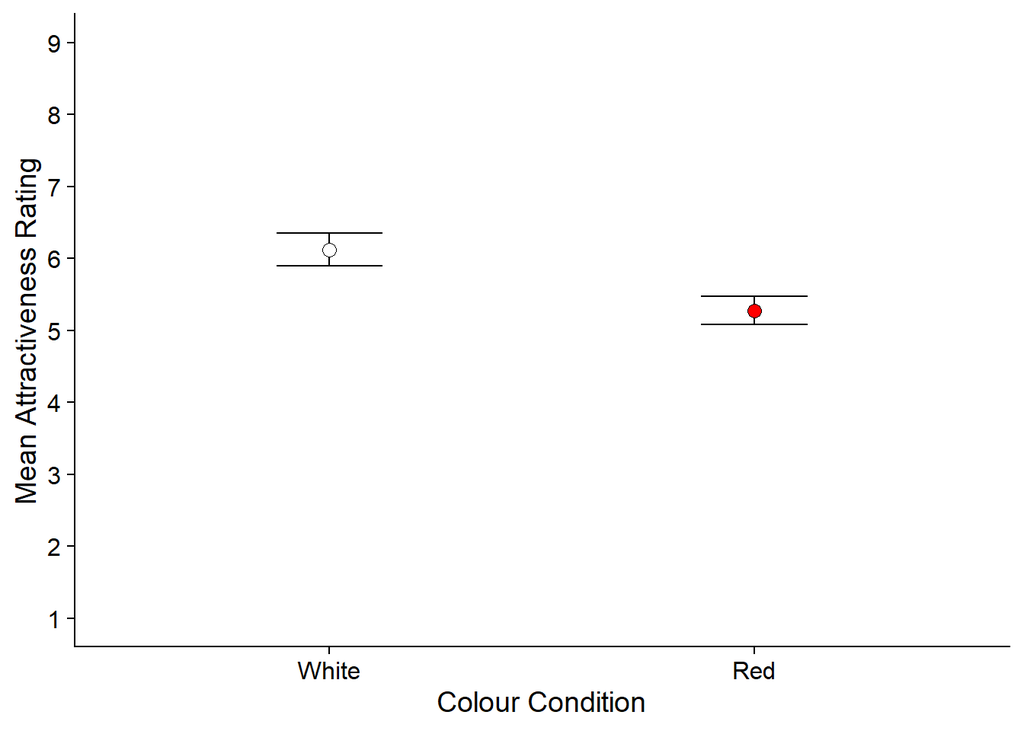

Figure 1. Relationship between mean attractiveness rating by conditions. Vertical lines represent standard errors. Horizontal lines represent confidence of interval.

# Discussion

The present experiment is a replication of Experiment 1 from Elliot et al. (2010), and it aimed to evaluate whether the presence of red cues influences women’s ratings of men’s attractiveness. The results, in disagreement with our hypothesis, indicated that red does not enhance women’s perceptions of the attractiveness of men. Specifically, results yielded that colour white is significantly associated with higher attractiveness scores.

However, these results showed a reverse pattern compared to those obtained by Elliot et al. (2010), which reported that red positively affects attractiveness’ ratings. This opposite pattern of results undermines the solidity of the red effect theory and supports Francis’ (2013) comment, according to which, Elliot et al.’s (2010) findings are likely to be impaired by some form of publication bias. The estimated power, the experiments’ probability of rejecting the null hypothesis, of Elliot et al.’s (2010) experiments is lower than the frequency of results reported to successfully reject the null hypothesis. Moreover, the p-value of the present study (*p*<.001) is more significant than the mean p-value of Elliot et al.’s Experiment 1 (*p*<.05). This means that, although both findings are statistically significant, the probability that our results occurred by chance is lower than the probability that Elliot et al.’s (2010) results happened by chance. However, our results are at odds also with experiments where participants’ judgment did not differ at all across color conditions (Elliot & Maier, 2013; Hesslinger, Goldbach, & Carbon, 2015). Similarly to our pattern of results, Peperkoorn, Roberts, and Pollet (2016) reported a slightly significant white effect on attractiveness in their experiment 1. However, their study concerns men’s perception of women’s attractiveness.

Some limitations need to be taken into account. In the present, such as in other research studies (Elliot et al., 2010; Elliot & Maier, 2013; Hesslinger, Goldbach, & Carbon, 2015), the number of participants in each sample is not big enough. According to Francis (2013), each sample should count at least 103 participants in order to reliably test the red-attractiveness effect. It follows that further research on larger samples of participants is necessary to support or deny the red-attraction link. Also, in our study, the range of participants’ age was limited, future research should recruit older female participants as well. Another point to consider is whether researching about this effect is practically and theoretically important. As Hesslinger, Goldbach, and Carbon, (2015) pointed out, these findings are not ecologically valid given that in real life there are other variables, such as apparel style, which may influence perceived attractiveness to a greater extent, mitigating the red-effect on perceived attractiveness. On the other hand, a strength of Eliot et al. (2010) and our research is the wide range of cultural diversity among participants. This allows us to exclude culture as a nuisance variable. Future research should focus on examining the red effect in more naturalistic situations and reflect the variability of appearance present among men in nature. Participants should meet the target men in person, in contexts analogous to real-life encounters. Moreover, experiments should involve over 103 participants for each condition. I appreciate that these conditions will make the experiment problematic to take place, both in terms of timing and recruiting the needed amount of participants and men model. Also, the complexity of the aforementioned design will increase the risk of involving contaminants in the experiment. Nevertheless, such an experiment would assure ecologically valid findings.

In conclusion, we replicated Elliot et al.’s (2010) first experiment to test for the red effect on women’s evaluations of men. In contrast with the original study and our hypothesis, attractiveness was not found to be higher when related to colour red but rather when related to colour white. It follows that the red-attraction link still lacks scientific evidence and further research is needed. Finally, I suggest that future studies recruit a larger number of participants and that their experimental designs guarantee ecologically valid results.

# References

Elliot, A. J., Niesta Kayser, D., Greitemeyer, T., Lichtenfeld, S., Gramzow, R. H., Maier, M. A., & Liu, H. (2010). Red, rank, and romance in women viewing men. *Journal of Experimental Psychology: General, 139*(3), 399–417.

Elliot, A. J., & Maier, M. A. (2013). The red-attractiveness effect, applying the ioannidis and trikalinos (2007b) test, and the broader scientific context: A reply to francis (2013). *Journal of Experimental Psychology: General, 142*(1), 297-300.

Francis, G. (2013). Publication bias in “Red, rank, and romance in women viewing men,” by elliot et al. (2010). *Journal of Experimental Psychology: General, 142*(1), 292-296.

Hesslinger, V. M., Goldbach, L., & Carbon, C.-C. (2015). Men in red: A reexamination of the red-attractiveness effect. *Psychonomic Bulletin & Review, 22*(4), 1142–1148.

Peperkoorn, L. S., Roberts, S. C., & Pollet, T. V. (2016). Revisiting the Red Effect on Attractiveness and Sexual Receptivity: No Effect of the Color Red on Human Mate Preferences. *Evolutionary Psychology*.